# How to be successful on Kickstarter

Ann Rajaram

January 29, 2018

In this tutorial, we will explore the characterisitcs of projects on Kickstarter and try to understand what separates the winners from the projects that failed to reach their funding goals.

## Qs for Exploratory Analysis:

We will start our analysis with the aim of answering the following questions:

## Predicting success rates:

Using the answers from the above questions, we will try to create a model that can predict which projects are most likely to be successful.  
If you like this tutorial, feel free to fork the script. And dont forget to upvote the kernel! :)

## Step1 - Data Pre-processing

### a) Let us take a look at the input dataset :

```
## 'data.frame':    378661 obs. of  15 variables:
##  $ ID              : int  1000002330 1000003930 1000004038 1000007540 1000011046 1000014025 1000023410 1000030581 1000034518 100004195 ...
##  $ name            : chr  "The Songs of Adelaide & Abullah" "Greeting From Earth: ZGAC Arts Capsule For ET" "Where is Hank?" "ToshiCapital Rekordz Needs Help to Complete Album" ...
##  $ category        : chr  "Poetry" "Narrative Film" "Narrative Film" "Music" ...
##  $ main_category   : chr  "Publishing" "Film & Video" "Film & Video" "Music" ...
##  $ currency        : chr  "GBP" "USD" "USD" "USD" ...
##  $ deadline        : chr  "2015-10-09" "2017-11-01" "2013-02-26" "2012-04-16" ...
##  $ goal            : num  1000 30000 45000 5000 19500 50000 1000 25000 125000 65000 ...
##  $ launched        : chr  "2015-08-11 12:12:28" "2017-09-02 04:43:57" "2013-01-12 00:20:50" "2012-03-17 03:24:11" ...
##  $ pledged         : num  0 2421 220 1 1283 ...
##  $ state           : chr  "failed" "failed" "failed" "failed" ...
##  $ backers         : int  0 15 3 1 14 224 16 40 58 43 ...
##  $ country         : chr  "GB" "US" "US" "US" ...
##  $ usd.pledged     : num  0 100 220 1 1283 ...
##  $ usd_pledged_real: num  0 2421 220 1 1283 ...
##  $ usd_goal_real   : num  1534 30000 45000 5000 19500 ...
```

We can see how many people are backing each individual project using the column, “backers”.

The name doesn’t really indicate any specific pattern although it might be interesting to see if longer names have better success rates. Not pursuing that angle at this time, though.

```
##           ID                                                       name
## 1 1000002330                            The Songs of Adelaide & Abullah
## 2 1000003930              Greeting From Earth: ZGAC Arts Capsule For ET
## 3 1000004038                                             Where is Hank?
## 4 1000007540          ToshiCapital Rekordz Needs Help to Complete Album
## 5 1000011046 Community Film Project: The Art of Neighborhood Filmmaking
## 6 1000014025                                       Monarch Espresso Bar
##         category main_category currency   deadline  goal
## 1         Poetry    Publishing      GBP 2015-10-09  1000
## 2 Narrative Film  Film & Video      USD 2017-11-01 30000
## 3 Narrative Film  Film & Video      USD 2013-02-26 45000
## 4          Music         Music      USD 2012-04-16  5000
## 5   Film & Video  Film & Video      USD 2015-08-29 19500
## 6    Restaurants          Food      USD 2016-04-01 50000
##              launched pledged      state backers country usd.pledged
## 1 2015-08-11 12:12:28       0     failed       0      GB           0
## 2 2017-09-02 04:43:57    2421     failed      15      US         100
## 3 2013-01-12 00:20:50     220     failed       3      US         220
## 4 2012-03-17 03:24:11       1     failed       1      US           1
## 5 2015-07-04 08:35:03    1283   canceled      14      US        1283
## 6 2016-02-26 13:38:27   52375 successful     224      US       52375
##   usd_pledged_real usd_goal_real
## 1                0       1533.95
## 2             2421      30000.00
## 3              220      45000.00
## 4                1       5000.00
## 5             1283      19500.00
## 6            52375      50000.00
```

### c) Looking for missing values:

```r
# Check for NAs:
sapply(ksdf, function(x) sum(is.na(x)))
```

```
##               ID             name         category    main_category
##                0                0                0                0
##         currency         deadline             goal         launched
##                0                0                0                0
##          pledged            state          backers          country
##                0                0                0                0
##      usd.pledged usd_pledged_real    usd_goal_real
##             3797                0                0
```

```r
# Check for empty strings:
nrow(subset(ksdf, is.na(ksdf$name)))
```

```
## [1] 0
```

```r
nrow(subset(ksdf, is.na(ksdf$category)))
```

```
## [1] 0
```

```r
nrow(subset(ksdf, is.na(ksdf$main_category)))
```

```
## [1] 0
```

```r
nrow(subset(ksdf, is.na(ksdf$state)))
```

```
## [1] 0
```

### d) Date Formatting and splitting:

We have two dates in our dataset - “launch date” and “deadline date”.We convert them from strings to date format.  
We also split these dates into the respective year and month columns, so that we can plot variations over time.  
So we will now have 4 new columns: launch_year, launch_month, deadline_year and deadline_month.

```
##           ID                                                       name
## 1 1000002330                            The Songs of Adelaide & Abullah
## 2 1000003930              Greeting From Earth: ZGAC Arts Capsule For ET
## 3 1000004038                                             Where is Hank?
## 4 1000007540          ToshiCapital Rekordz Needs Help to Complete Album
## 5 1000011046 Community Film Project: The Art of Neighborhood Filmmaking
##   main_category launch_year launch_mth final_year final_mth
## 1    Publishing        2015    2015-08       2015   2015-10
## 2  Film & Video        2017    2017-09       2017   2017-11
## 3  Film & Video        2013    2013-01       2013   2013-02
## 4         Music        2012    2012-03       2012   2012-04
## 5  Film & Video        2015    2015-07       2015   2015-08
```

## Exploratory analysis:

### a) How many projects are successful?

```r
prop.table(table(ksdf$state))*100
```

```
##
##   canceled     failed       live successful  suspended  undefined
## 10.2410864 52.2153060  0.7391836 35.3762336  0.4875073  0.9406831
```

We see that “failed” and “successful” are the two main categories, comprising ~88% of our dataset.  
Sadly we do not know why some projects are marked “undefined” or “canceled”.  
“live”" projects are those where the deadlines have not yet passed, although a few among them are already achieved their goal.  
Surprisingly, some ‘canceled’ projects had also met their goals (pledged_amount >= goal).  
Since these other categories are a very small portion of the dataset, we will subset and only consider records with satus “failed” or “successful” for the rest of the analysis.

### b) How many countries have projects on kickstarter?

```
##
##     AT     AU     BE     CA     CH     DE     DK     ES     FR     GB
##    485   6616    523  12370    652   3436    926   1873   2520  29454
##     HK     IE     IT     JP     LU     MX  N,0""     NL     NO     NZ
##    477    683   2369     23     57   1411    210   2411    582   1274
##     SE     SG     US
##   1509    454 261360
```

We see projects are overwhelmingly US. Some country names have the tag N,0“”, so marking them as unknown.

### c) Number of projects launched per year:

```
##
##  2009  2010  2011  2012  2013  2014  2015  2016  2017
##  1179  9577 24049 38480 41101 59306 65272 49292 43419
```

Looks like some records say dates like 1970, which does not look right. So we discard any records with a launch / deadline year before 2009.  
Plotting the counts per year on a graphs: < br />From the graph below, it looks like the count of projects peaked in 2015, then went down. However, this should NOT be taken as an indicator of success rates.

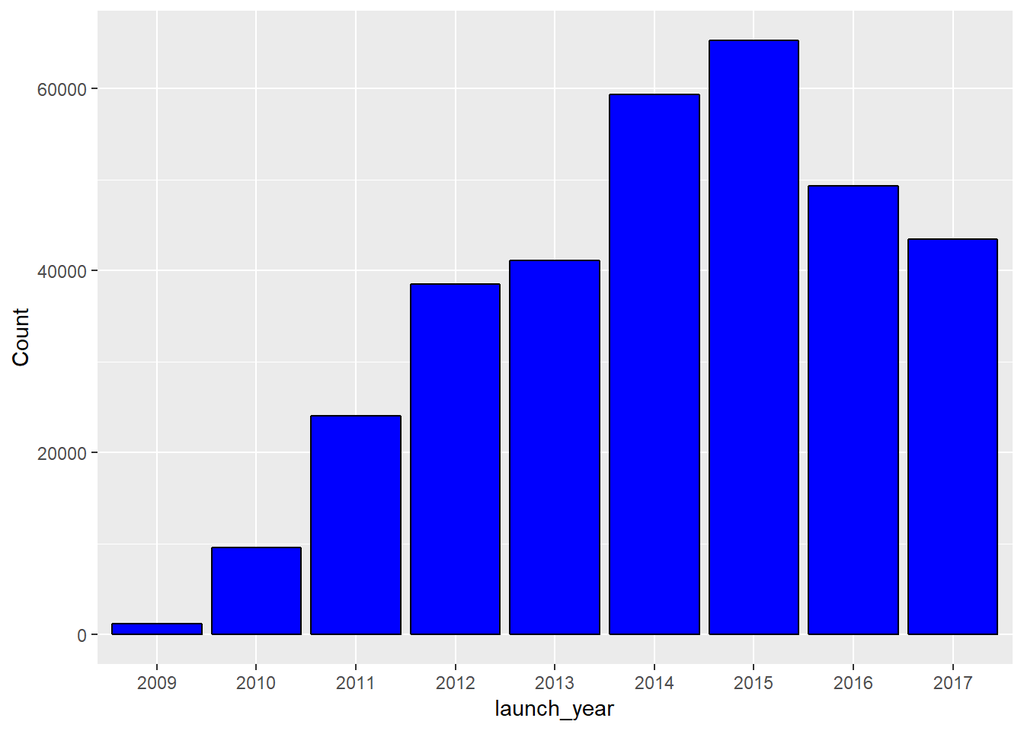

Drilling down a bit more to see count of projects by main_category.

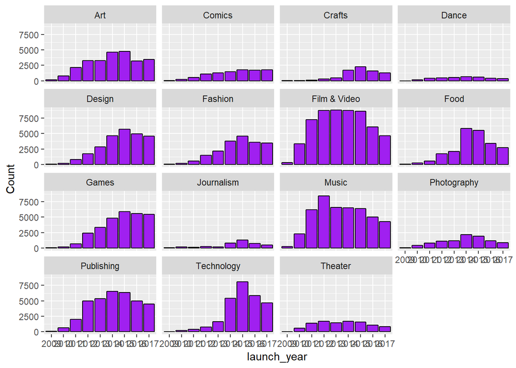

Over the years, maximum number of projects have been in the categories:

1. Film & Video
2. Music
3. Publishing

### d) Number of projects by sub-category: (Top 20 only)

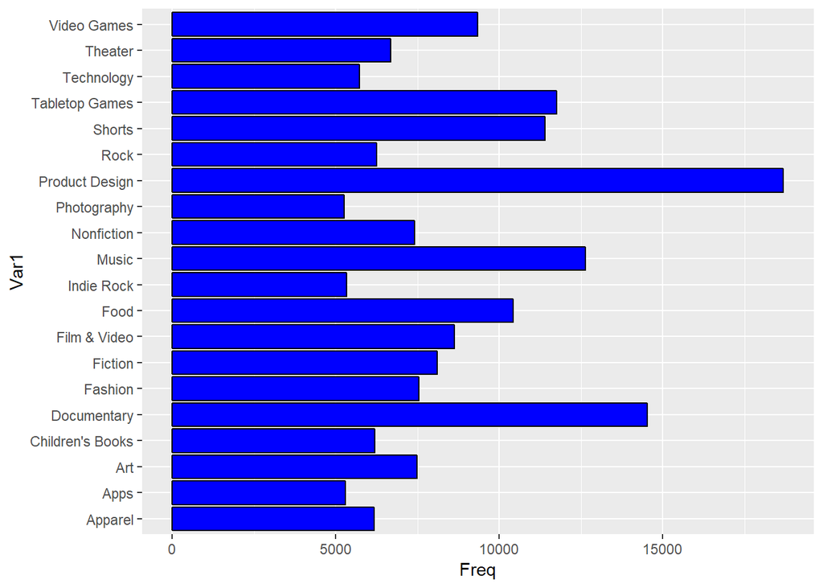

The Top 5 sub-categories are:

1. Product Design
2. Documentary
3. Music
4. Tabletop Games (interesting!!!)
5. Shorts (really?! )

Let us now see “Status” of projects for these Top 5 sub_categories:  
From the graph below, we see that for category “shorts” and “tabletop games” there are more successfull projects than failed ones.

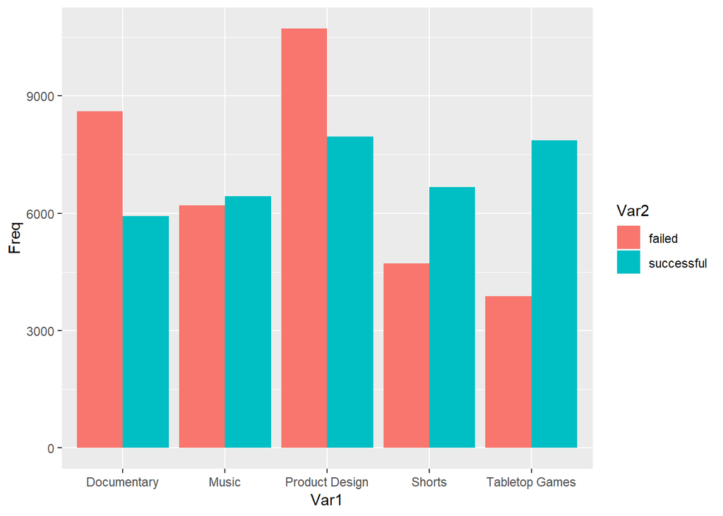

### e) Backers by category and sub-category:

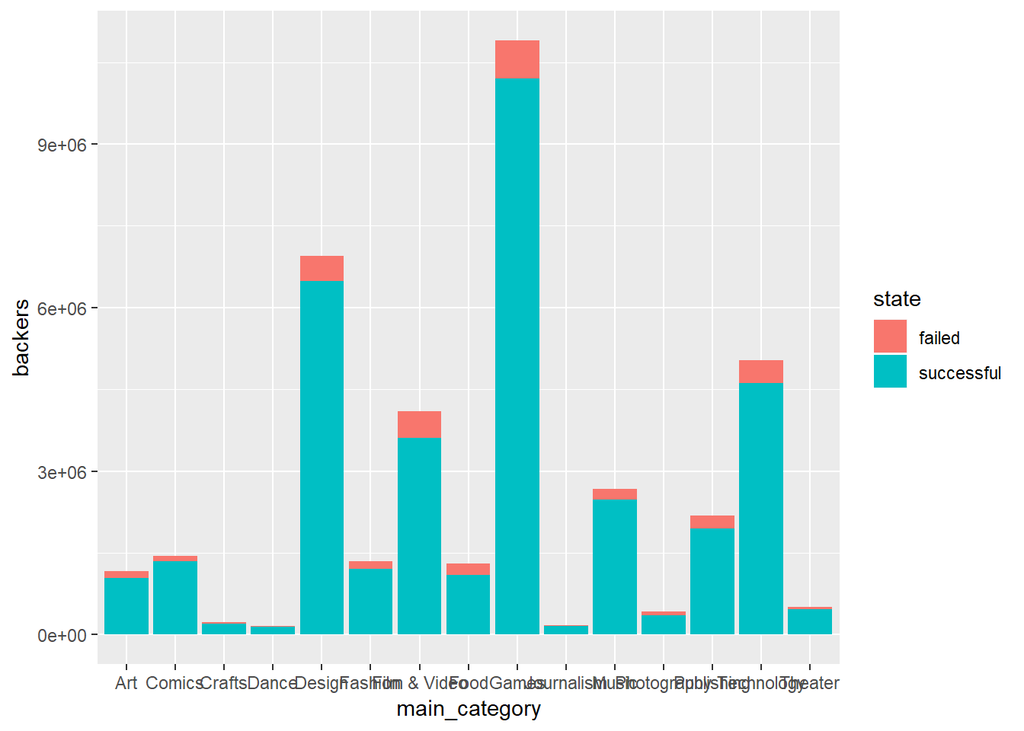

Since there are a lot of sub-categories, let us explore the sub-categories under the main theme “Design”

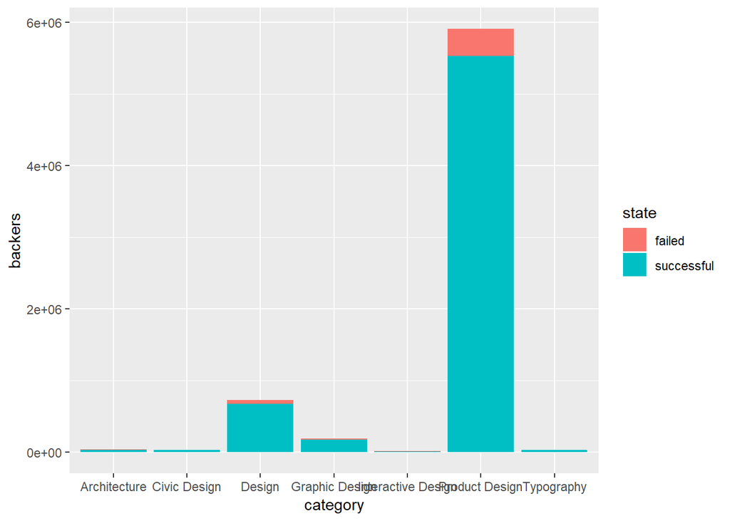

### f) add flag to see how many got funded more than the goal.

```r
ksdf$goal_flag <- ifelse(ksdf$pledged >= ksdf$goal, 1, 0)
prop.table(table(ksdf$goal_flag))*100
```

```
##
##        0        1
## 59.61197 40.38803
```

So ~40% of projects reached or surpassed their goal, which matches the number of successful projects .

### g) Calculate average contribution per backer:

```r
summary(ksdf$contrib)
```

```
##     Min.  1st Qu.   Median     Mean  3rd Qu.     Max.
##     0.00    16.00    41.78    73.35    78.00 50000.00
```

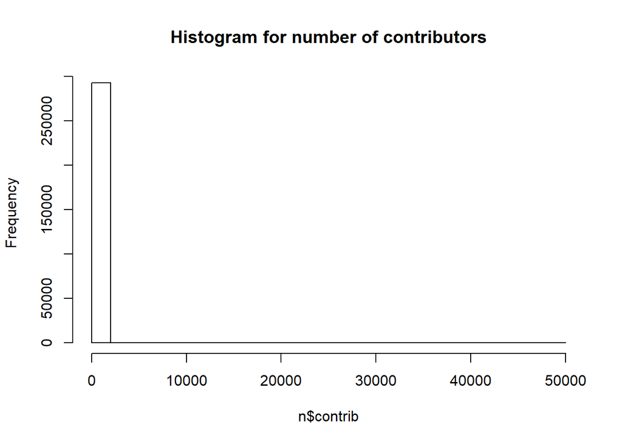

```r
hist(n$contrib, main = "Histogram for number of contributors")
```

### h) Calculate reach_ratio

The amount per backer is a good start, but what if the goal amount itself is only $1000? Then an average contribution per backer of $50 impies we only need 20 backers.  
So to better understand the probability of a project’s success, we create a derived metric called “reach_ratio”.  
This takes the average user contribution and compares it against the goal fund amount.

```
##      Min.   1st Qu.    Median      Mean   3rd Qu.      Max.
##      0.00      0.16      0.75      6.17      2.16 166666.67
```

We see the median reach_ratio is <1%. Only in the third quartile do we even touch 2%!  
Clearly most projects have a very low reach ratio. We could subset for “successful” projects only and check if the reach_ratio is higher.

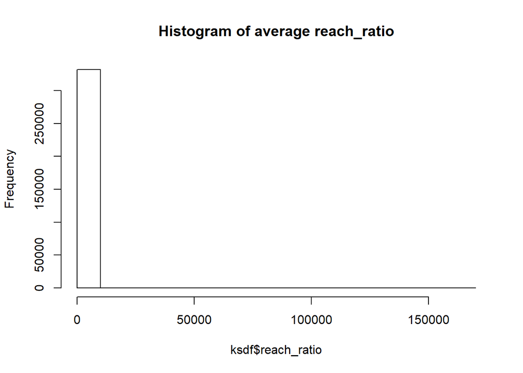

### i) Number of days to achieve goal:

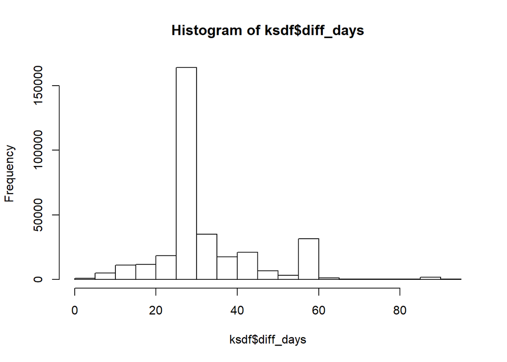

## Predictive Analystics:

We will apply a very simple decision tree algorithm to our dataset.  
Since we do not have a separate “test” set, we will split the input dataframe into 2 parts (70/30 split).  
We will use the smaller set to test the accuracy of out algorithm.

```r
ksdf$status = ifelse(ksdf$state == 'failed', 0, 1)

## 70% of the sample size
smp_size <- floor(0.7 * nrow(ksdf))

## set the seed to make your partition reproductible
set.seed(486)
train_ind <- sample(seq_len(nrow(ksdf)), size = smp_size)

train <- ksdf[train_ind, ]
test <- ksdf[-train_ind, ]
```

```r
library(tree)
tree1 <- tree(status ~ goal + reach_ratio + category + backers + country + launch_year , data = train)
summary(tree1)
```

```
##
## Regression tree:
## tree(formula = status ~ goal + reach_ratio + category + backers +
##     country + launch_year, data = train)
## Variables actually used in tree construction:
## [1] "backers"     "reach_ratio"
## Number of terminal nodes:  9
## Residual mean deviance:  0.02429 = 5640 / 232200
## Distribution of residuals:
##       Min.    1st Qu.     Median       Mean    3rd Qu.       Max.
## -0.9816000 -0.0006945 -0.0006945  0.0000000  0.0410400  0.9993000
```

Taking a peek at the decision tree rules:

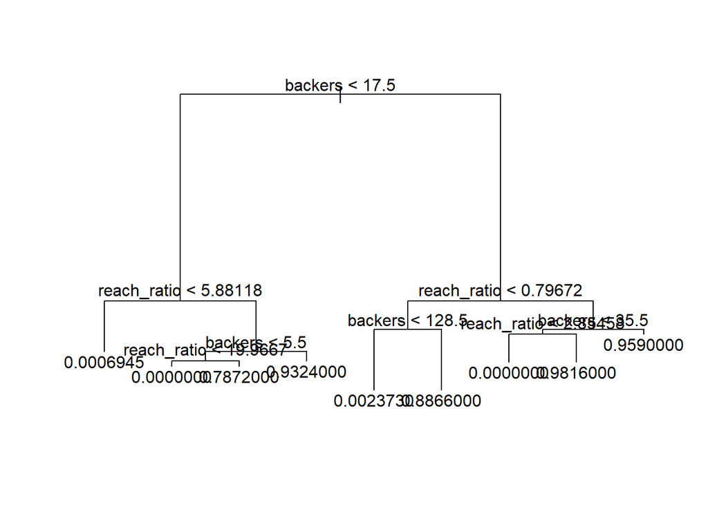

```r
plot(tree1)
text(tree1 ,pretty =0)
```

```r
tree1
```

```
## node), split, n, deviance, yval
##       * denotes terminal node
##
##  1) root 232172 55900.00 0.4039000
##    2) backers < 17.5 121911  9326.00 0.0834600
##      4) reach_ratio < 5.88118 107986    74.95 0.0006945 *
##      5) reach_ratio > 5.88118 13925  2774.00 0.7253000
##       10) backers < 5.5 4723  1031.00 0.3218000
##         20) reach_ratio < 19.9667 2792     0.00 0.0000000 *
##         21) reach_ratio > 19.9667 1931   323.50 0.7872000 *
##       11) backers > 5.5 9202   580.00 0.9324000 *
##    3) backers > 17.5 110261 20210.00 0.7583000
##      6) reach_ratio < 0.79672 40852 10190.00 0.5217000
##       12) backers < 128.5 16858    39.91 0.0023730 *
##       13) backers > 128.5 23994  2413.00 0.8866000 *
##      7) reach_ratio > 0.79672 69409  6383.00 0.8975000
##       14) backers < 35.5 20535  3836.00 0.7514000
##         28) reach_ratio < 2.85458 4816     0.00 0.0000000 *
##         29) reach_ratio > 2.85458 15719   284.60 0.9816000 *
##       15) backers > 35.5 48874  1924.00 0.9590000 *
```

Re-applying the tree rules to the training set itself, we can validate our model:

```r
Predt <- predict(tree1, train)
validf <- data.frame( kickstarter_id = train$ID, orig_status = train$status, new_status = Predt)
validf$new = ifelse(validf$new_status < 0.5, 0, 1)

# contingency Tables:
table(validf$orig_status, validf$new)
```

```
##
##          0      1
##   0 132337   6051
##   1    115  93669
```

```r
# Area under the curve
library(pROC)
auc(validf$orig_status, validf$new)
```

```
## Area under the curve: 0.9775
```

From the above tables, we see that the error rate = ~3% and area under curve >= 97%

Finally applying the tree rules to the test set, we get the following stats:

```r
Pred1 <- predict(tree1, test)
chkdf <- data.frame( kickstarter_id = test$ID, orig_status = test$status, new_status = Pred1)
chkdf$new = ifelse(chkdf$new_status < 0.5, 0, 1)

# contingency Tables:
table(chkdf$orig_status, chkdf$new)
```

```
##
##         0     1
##   0 56771  2560
##   1    42 40130
```

```r
# Area under the curve
library(pROC)
auc(chkdf$orig_status, chkdf$new)
```

```
## Area under the curve: 0.9779
```

From the above tables, we see that still the error rate = ~3% and area under curve >= 97%

## Conclustion:

If you liked this tutorial, feel free to fork the script. And dont forget to upvote the kernel! :)